# Tommaso Feraco

**Curriculum Vitae**

## Personal information

**Last name:** Feraco  
**First name:** Tommaso  
**Birth date:** 26/03/1993  
**Address:** Via Antonio Stoppani 22C, Padova (PD), Italy, 35136  
**E-mail:** tommaso.feraco@unipd.it  
**Website:** https://feracotommaso.github.io/

## Current position

**05/2026 – current**

**Tenure-track researcher** (M/PSI-01), Department of General Psychology, University of Padova.

## Past work experience

**08/2024 – 05/2026**

**Junior Assistant Professor / Fixed term researcher** (M/PSI-01), Department of General Psychology, University of Padova.

**11/2023 – 07/2024**

**Post-doc** position (research grant – M/PSI-01), Department of General Psychology, University of Padova. Project: “*Soft-LD: Softening Learning Disabilities: the role of soft skills in students with Specific Learning Disabilities*”. Supervisor: Prof. Chiara Meneghetti.

**11/2022 – 10/2023**

**Post-doc** position (research grant – M/PSI-01), Department of General Psychology, University of Padova. Project: “*Unlocking soft skills*”. Supervisor: Prof. Chiara Meneghetti.

**11/2021 – 10/2022**

**Post-doc** position (M/PSI-01), Department of General Psychology, University of Padova. Project: “*BeBrEvo “Trade-offs in human Behaviour and Brain: a (r)Evolutionary approach*”. Supervisor and PI: Prof. Giorgia Cona.

**2018 – 2021**

**PhD student** in Psychological Sciences, Department of General Psicology, University of Padova. Thesis: “S*oft skills, study-related factors, wellbeing, and academic achievement in 10-18 years old students*” Supervisor: Prof. Chiara Meneghetti. Defense date: 21/02/2022.

**2018 – 2021**

**Head of Research**, DUYU (Pentathlon S.r.l.) in collaboration with the University of Padova, Project “*Beable: Analysis of the abilities influencing scholastic choice and achievement. Studying the XXI century skills*”.

## Education and qualifications

**06/2025**

**National Scientific Qualification** (ASN), PSIC-01A

**02/2022**

**PhD** in Psychological Sciences, Department of General Psychology, University of Padova.

**02/2021**

National qualification to the psychologist profession.

**09/2017 – 08/2018**

**Postgraduate Program** in Learning Tutor, Department of General Psychology, University of Padova.

**03/2018 – 08/2018**

**Research internship**, Department of General Psychology, University of Padova. Supervisor: prof. Chiara Meneghetti

**09/2017 – 02/2018**

**Post-graduate internship**, Istituto Padre Monti, Saronno, Italy. Supervisor: Dr. Mariagrazia Banfi.

**12/07/2017**

**Master’s degree** in Applied Cognitive Psychology, Department of General Psychology, University of Padova. Thesis: “*Spatial updating in case of an abrupt displacement during locomotion*”. Supervisor: Prof. Chiara Meneghetti.

**12/07/2015**

**Bachelor’s degree** in Psychological Sciences and Techniques, University of Milano Bicocca. Thesis: “*Human cognition and analogies*”. Supervisor: Prof. Laura Macchi.

## Additional training

**12/2022**

**ESM Data Analysis** Course, Maastrictht University, Prof. Wolfgang Viechtbauer (https://www.wvbauer.com/doku.php/course_esmda; 25 hours).

**26/1 & 2/2/2023**

Course on principles and strategies of **effective communication**, debates, dialogic rules, and controversy management, University of Padova, prof. Adelino Cattani, prof. Bruno Mastroianni, and prof. Maria Grazia Busà (4 hours).

**23/09/2021**

**Educational and Career Guidance**: Innovative Perspectives at the University of Padova, University of Padova (https://www.unipd.it/news/orientamento-visioni-innovative-unipd; 8 hours).

**02/2021**

**Meta-Analysis Course**, Maastrictht University, Prof. Wolfgang Viechtbauer (https://www.wvbauer.com/doku.php/course_ma; 25 hours).

**06/2021**

Summer school: **Bayesian Statistical Analyses** for the Human, Social and Cognitive Sciences, University of Verona (https://sites.hss.univr.it/bayeshsc/; 37 hours).

## Teaching

### Teaching activity

| Course | Level | Degree | Year | Hours / CFU |
| --- | --- | --- | --- | --- |
| Structural Equation Models | PhD | Psychological Sciences, University of Padova | 25/26 \| 23/24 | 20 (5) \| 16 (4) |
| Psychology of Learning and Well-Being at School | MC | Applied Cognitive Psychology, University of Padova | 24/25 | 21 (3) |
| Personality and Individual Differences | BC | Developmental, Personality, and Interpersonal Relationships Psychology, University of Padova | 25/26 \| 24/25 | 21 (3) \| 21 (3) |
| Personality and Individual Differences | BC | Psychological Sciences and Techniques, University of Padova | 25/26 | 21 (3) |
| Personality and Individual Differences | BC | Social and Organizational Psychology, University of Padova | 25/26 | 21 (3) |
| Soft skills and learning disabilities (lesson) | PG | Learning Psychopathology, University of Padova | 25/26 \| 23/24 | 2 \| 4 |
| Social emotional and behavioral skills in students (seminar) | PhD | University of Genova | 23/24 | 2 |

### Teaching assistant activity

| Course | Level | Degree | Year | Hours / CFU |
| --- | --- | --- | --- | --- |
| Personality and Individual Differences | BC | Developmental, Personality, and Interpersonal Relationships Psychology, University of Padova | 23/24 \| 22/23 | 28h \| 14h |
| Personality and Individual Differences | BC | Psychological, cognitive and psychobiological sciences, University of Padova | 23/24 | 15h |
| Spatial cognition | BC | Psychological Sciences, University of Padova | 18/19 \| 19/20 \| 20/21 \| 21/22 \| 22/23 | 15h \| 15h \| 15h \| 15h \| 15h |

### Invited lectures

**30/11/2023**

“*Social emotional and behavioral skills in boys and girls with specific learning disabilities*”. Bachelor course in Psychology, University of Genova (**2 hours**).

**09/03/2023**

“*Let’s discover the soft skills needed to solve a group problem*”. Bachelor course in Electronic Engineering, University of Padova (**2 hours**).

**23/11/2022**

“*Development of Intelligence in Adolescence: Age and Gender Effects*”. Bachelor course in Psychology, University of Genova (**2 hours**).

**23/10/2022**

“*Soft skills*”. Bachelor course in Education, University of Padova.

**06/05/2020**

“*The role of soft skills and study-related factors in fostering students’ academic achievement and life satisfaction*”. University of Paris Descartes (**2 hours**).

### Supervision activities

**2018 – current**

Supervisor of 1 master and 6 bachelor students and co-supervisor of 17 master and 26 bachelor students at the Department of General Psychology, University of Padova, Italy.

### Participation in Degree Examination Committees

**2024 – ad oggi**

Master’s Degree Thesis Committees, School of Psychology, University of Padova.

**2024 – ad oggi**

Preparatory Committees for Bachelor’s Degree Programs, School of Psychology, University of Padova.

**2024 – ad oggi**

Final Degree Awarding Committees for Bachelor’s Degree Programs, School of Psychology, University of Padova.

**27/02/2026**

PhD Thesis Committee, University of Milano Bicocca.

### Cultore della materia

**2023**

Psicologia della personalità e delle differenze individuali. Corso di Laurea Triennale in Scienze Psicologiche dello Sviluppo, della Personalità e delle Relazioni Interpersonali. Università degli Studi di Padova.

## Research experience abroad

**2025**

Visiting researcher, St. Gallen University, Switzerland (1 month: 15/08/25-15/09/25).

**2021**

Visiting researcher, University of Paris V: René Descartes. Supervisor: prof. Franck Zenasni (1 month: 30/08/21-30/09/21).

**2017**

Research internship, University of Cyprus. Supervisor: prof. Marios Avraamides (4 months: 28/8/17-22/12/17).

## Public engagement

- Talks and debates for high school students. Project: “Scegli con noi”, University of Padova (https://scegliconnoi.unipd.it/)

**21/02/2024**

**Talk**: “*La psicologia che non ti aspetteresti*”. https://scegliconnoi.unipd.it/evento/la-psicologia-che-non-ti-aspetteresti/

**20/02/2024**

**Debate**: “*Le idee che abbiamo della psicologia sono vere? False? Sia vere che false? Botta e risposta tra esperti*”. https://scegliconnoi.unipd.it/evento/le-idee-che-abbiamo-della-psicologia-sono-vere-false-sia-vere-che-false-botta-e-risposta-tra-esperti/

**14/02/2023**

**Talk**: “*La psicologia che non ti aspetti*”. https://scegliconnoi.unipd.it/evento/lo-psicologo-che-non-ti-aspetti-3/

**13/02/2023**

**Debate**: “*Sarà vero? Sarà falso? La psicologia ti aiuta a capirlo. Botta e Risposta tra esperti*”. https://scegliconnoi.unipd.it/evento/misconception-della-psicologia/

- Lessons for high school students. Project: “*PnrrOrienta*”, University of Padova (https://pnrrorienta.unipd.it/)

**2024 – 2026**

**Proposer and teacher** for the course: “*Competenze trasversali: un laboratorio esperienziale e di scienza psicologica*”. 7 lessons, 21 hours.

**2023 – 2026**

**Teacher** for the course “*Studiare bene, anzi studiare meglio: una chiave di successo per l’Università*”. 1 lesson, 3 hours.

**2023 – 2024**

**Online course** for high school students: “*Destinazione Università: Soft skills e abilità di studio per scegliere l’università con successo*”. Responsibles: Tommaso Feraco, Roberta Bonelli, Chiara Meneghetti, Lorenza Da Re. Participants: 3000+.

- Dissemination seminars for high school students. Project: “Unipadova incontra”, University of Padova (https://www.unipd.it/unipadova-incontra)

**2022**

28/04: Liceo G. Galilei: “*Memory and Learning*”. 22/04: Liceo Marchesi: “*Memory and Learning*”. 30/03: Liceo Duca degli Abruzzi: “*21st Century Skills at School*”.

**2021**

20/04: Liceo Caro: “*Memory and Learning*”. 17/03: Liceo Riccati-Luzzatti: “*21st Century Skills at School*”. 16/03: Liceo Duca degli Abruzzi: “*Memory and Learning*”.

**2019**

13/02: Liceo Stefanini: “*Memory and Learning*”.

- Dissemination seminars and activities for the public. Projects: “European Researchers Night – Veneto night” (https://venetonightpadova.it/) and “Science for All” (https://science4all.it/). University of Padova

**14/11/2023**

Lesson for primary school children: “*Creativa-Mente: pensare in modo creativo*”. Responsibles: Chiara Meneghetti, Barbara Carretti, Tommaso Feraco, Gerardo Pellegrino.

**30/09/2023**

Activity for the general population: “*riCREAre: pensare in modo creativo*”. Responsibles: Chiara Meneghetti, Barbara Carretti, Tommaso Feraco, Gerardo Pellegrino.

**30/09/2022**

Activity for the general population: “*Giochiamo con la creatività e l’intelligenza emotiva!*”. Responsibles: Tommaso Feraco, Nicole Casali, Chiara Meneghetti.

**24/09/2021**

Lesson for high school students “*Study Well (Not Too Much!)* …*The Role of Learning Strategies, Motivation, and 21st Century Skills*”. Held by Chiara Meneghetti & Tommaso Feraco.

**25/09/2020**

Lesson for high school students: “*The Student of the 21st Century: Strategies and Skills for School and Future Success*”. Held by Chiara Meneghetti & Tommaso Feraco.

### Other talks, seminars, and debates

**24/05/2023**

Debate: “*Exams Don’t Work*”, speaker at the third psycho-debate of the School of Psychology, University of Padova.

**23/09/2022**

Talk: “*Studiare Psicologia a Padova*”, International workshop on Educational and Professional Orientation, University of Padova.

### Other activities

**11/2022 –3/2023**

Official responsible for the creation, supervision, and implementation of a video for the promotion of the School of Psychology, University of Padova. Name of the project: “*Realizzazione di video di presentazione rivolti a studentesse e studenti delle scuole secondarie di secondo grado italiane e internazionali con la presentazione delle principali informazioni del perché studiare psicologia a Padova*”.

## Awards and grants

### Research awards

**2023**

Valiant award for the best presentation (third place): **Feraco, T.** & Giorgia, C. (2023). *Happy children! A network and longitudinal analysis of positive affect’s predictors in adolescence.* Cognitive Science Arena, 10-11 February.

**2022**

2022 Travel Award – Journal of Intelligence, for the best presentation: **Feraco, T.** & Giorgia, C. (2022). *The age-and-gender differentiation hypotheses. A “new” bifactor approach to study differentiation of general and specific components of intelligence*. ESCOP, 29 August – 01 September.

**2020**

Best poster presentation, **Feraco, T.**, Resnati, D., Fregonese, D., & Meneghetti, C. (2020): *Soft skill and self-regulated learning in middle and high school students.* Web-Conference AIRIPA, 25-26 September.

### Teaching awards

**2025**

Award for Innovative Teaching Practices Arqus Unipd, Project “PERSO-METRIcA (“Personality-Psychometrics”): Interactions Between Teachings for the Cross-Disciplinary Training of Psychological Skills,” presented by Prof. Chiara Meneghetti in collaboration with Prof. Massimo Nucci and Prof. Tommaso Feraco. University of Padua.

### Grants:

**2026**

Fondo Italiano per la Scienza (FIS-3) for the project “*Geographical Psychology of School Anxiety*”. Amount: 1.036.815,36€

**2025**

EAPP Collaborative Research Grant. Project:“*From personality to skill volitional change: Insights from Germany, Italy, and Turkey*”. Amount: 10.000€. Role: Co-PI.

**2024**

EAPP Networking and Travel Stipends. Project: “*The Geographical Psychology of School Anxiety*”. Amount: 5.000€. Role: PI.

**2023**

Post-doctoral fellowship for the project: *Soft-LD: Softening Learning Disabilities: the role of soft skills in students with Specific Learning Disabilities*. Department of General Psychology, University of Padova. Amount: 19.367€. Role: PI.

**2023**

Project of Relevant Interest for the Nation (PRIN): MUR’s grant for the project *Evaluation strategies to contrast university drop-out through empowerment and to design educational and career guidance practices.* Role: Team member. PI: Lorenza Da Re. Amount: 246.000€.

**2023**

Departmental Research Project (PRID): Departmental grant for the project *PIO: Perspective on Intelligence Ontogeny*. Role: Team member. PI: Lucia Regolin. Amount: 10.000€.

**2022**

Post-doctoral fellowship for the project “*Unlocking soft skills*”. Department of General Psychology, University of Padova. Amount: 19.367€. Role: PI.

**2021**

Erasmus+ Studio Grant: visiting PhD at the University of Paris V: René Descartes, France.

**2017**

Erasmus+ Studio Grant: four months exchange at the University of Cyprus under the supervision of professor Marios Avraamides.

**2017**

Scholarship “mille e una lode”, University of Padova. The scholarship was given to the top 4% students of each course based on credits and grades. Amount: 1000€.

## International collaborations

**Since 2025:**

Brent W. Roberts, University of Illinois, USA. Theme: personality, soft skills, personality change.

**Since 2024:**

Tobias Ebert, St Gallen University, Switzerland. Theme: geographical psychology.

**Since 2024:**

Nathan W. Hudson, Southern Methodist University, Dallas, USA. Theme: Volitional personality change.

**Since 2022:**

Samuel Greiff, university of Luxemburg, Luxemburg. Theme: intelligence, cognitive abilities, measurement.

**Since 2022:**

Ryan Niemiec, Chief Science & Education Officer of the VIA Institute on Character, US. Theme: character strengths.

**Since 2022:**

Cristopher Soto, Colby College, US. Theme: personality, assessment, soft skills.

**Since 2022:**

Chris Napolitano, University of Illinois, US. Theme: personality, assessment, soft skills.

**Since 2020:**

Franck Zenasnì, University of Paris V: René Descartes, France. Theme: soft skills, measurement.

**Since 2019:**

Petra Jansen, University of Regensburg, Germany. Theme: sport and visuospatial abilities.

**Since 2017**

Marios Avraamides, University of Cyprus, Cyprus. Theme: spatial cognition.

## Research groups

**Since 2025:**

SEB Skills Lab, Home of the BESSI. University of Illinois & Colby College, US (http://www.sebskills.com/our-team.html).

**Since 2024:**

Psicostat Core Team, University of Padova (https://psicostat.dpss.psy.unipd.it/pages/people.html).

**Since 2017:**

Memory and Learning Lab, Department of General Psychology, University of Padova (https://www.memoryandlearninglab.it/people/).

## Organization of scientific conferences

**2026**

1st International Online Conference on Human Intelligence. https://sciforum.net/event/IOCHI2026?section=#event_chair. Role: Member of the Scientific Committee.

**2025**

International Winter School 2025: The 4 Ms: Meta-research, Measurement, Multi-lab, and Multiverse data analysis in Behavioral Sciences 2018, Padova, Italy, https://winterschool4ms.dpg.unipd.it/. Role: Organizing team.

**2018**

EWIC 2018, Padova, Italy, http://easyconferences.eu/ewic2018/committees/. Role: Organizing team.

## Scientific associations

**2025 – current**

Association for Research in Personality (ARP).

**2025 – current**

International Society for the Study of Individual Differences (ISSID).

**2024 – current**

European Association of Personality Psychology (EAPP).

**2021 – current**

Associazione Italiana per la Ricerca e l’Intervento nella Psicopatologia dell’Apprendimento (AIRIPA).

**2018 – current**

Associazione Italiana di Psicologia (AIP) – experimental psychology.

**2018 – 2023**

European Association for Research on Learning and Instruction (EARLI).

**2022 – 2023**

European Society for Cognitive Psychology (ESCOP).

**2022 – 2025**

American Psychological Association (APA).

## Institutional positions

**2024 – current**

Junior Member of the Third Mission Committee, Department of General Psychology. University of Padova.

**2023 – 2024**

Representative of Post-Doctoral researchers, Department of General Psychology. University of Padova.

**2019 – 2021**

Representative of PhD students of Psychological Sciences. University of Padova.

## Editorial and reviewing activities

**2024 – 2026**

**Editorial board** of BMC Psychology.

**2024 – 2025**

**Guest editor** for the special issue “*Personality and Developmental Changes across the Life Span: Predictors, Assessment, and Impact*”. https://www.mdpi.com/journal/ejihpe/special_issues/YPBR7UO6CQ

**2022 – current**

**Reviewer board** of the Journal of Intelligence.

**2022 – 2024**

**Senior reviewer** for the JURE Conference of the Junior Researchers of EARLI.

**2020 – current**

**Ad hoc reviewer** for the following (23) journals: *British Journal of Educational Psychology; European Journal of Personality; Personality and Social Psychology Bulletin; European Journal of Psychology Open; Journal of Adolescence; European Journal of Psychology of Education; Heliyon; Journal of Happiness Studies; Journal of Intelligence; Journal of Psychology: Interdisciplinary and Applied; Psychology Research and Behavior Management; Personality and Individual Differences; Learning and Individual Differences; Humanities and Social Sciences Communication; Applied Psychology: An International Review; Annals of Medicine; TPM - Testing, Psychometrics, Methodology in Applied Psychology; Social Sciences & Humanities Open; Social Psychology of Education; Journal of Environmental Psychology; Journal of Research in Personality; Large-scale Assessments in Education; PLoS ONE*.

## Research impact indicators

*updated: 17/06/2026*

[output not shown]

*Scopus and Web of Science may not yet include the latest publications.*

## Publications

### Publications in peer-reviewed journals

**⅟** = first/last author; **✉** = corresponding author; **✝** = international co-authors  
= preregistered

= open data

= open materials

= open code

1

**⅟✉** **Feraco, T.**, Calderan, M., & Pellegrino, G. (2026). The Living SEB Skills Project: A Living Resource for Review and Meta-Analysis of Social, Emotional, and Behavioral Skills. *European Journal of Personality*, *0*(0). https://doi.org/10.1177/08902070261467477. *IF 2025: 4.8 (JCR: Q1, psychology – social; Scopus: Q1, psychology - social).*

2

Soltantouyeh, A., **Feraco, T.**, Agostinis, B. and Meneghetti, C. (2026) Dance to be creative: the creative beliefs, creativity ability and improvisation performance in experts, amateurs, and non-dancers. *Frontiers in Psychology. 17*:1670292. https://doi.org/10.3389/fpsyg.2026.1670292. *IF 2025: 3.8 (JCR: Q1, psychology, multidisciplinary; Scopus: Q1, general psychology).*

3

**⅟✉** **Feraco, T.**, Meneghetti, C., & Cornoldi, C. (2026). Use and Coherence of Study Skills and Learning-Strategy Knowledge in Typically Developing Children and Children With Specific Learning Disabilities. *Learning Disabilities Research & Practice*,*41(3)*, 162-171. https://doi.org/10.1177/09388982261422712. *IF 2025: 2.0 (JCR: Q1, education, special; Scopus: Q2, social sciences – education).*

4

**⅟✉** **Feraco, T.**, Pellegrino, G., Bonelli, R., Re, L. D., Carretti, B., & Meneghetti, C. (2026). Social, Emotional, and Behavioral Skills of Students With Specific Learning Disabilities: A Replication, Extension, and Synthesis of Existing Research. *Learning Disabilities Research & Practice*, 0(0). https://doi.org/10.1177/09388982261452122. *IF 2025: 2.0 (JCR: Q1, education, special; Scopus: Q2, social sciences – education).*

5

Dell’Acqua, C., Mologni, V., **Feraco, T.**, & Messerotti Benvenuti, S. (2026). A meta-analysis of the late positive potential for assessing affective processing in depression and depression vulnerability. *Journal of Affective Disorders*, 405, 121539. https://doi.org/10.1016/j.jad.2026.121539. *IF 2025: 5.7 (JCR: Q1, psychiatry; Scopus: Q1, clinical psychology).*

6

Pellegrino, G., **Feraco, T.**, De Vita, F., Martino, M. G., Matteucci, M. C., Montesano, L., Passolunghi, M. C., Re, A. M., Sini, B., Tinti, C., Valenti, A., Meneghetti, C., & Carretti, B. (2026). University Students With Specific Learning Disabilities: Do Soft Skills and Study-Related Factors Make a Difference to Their Academic Outcomes? *Journal of Learning Disabilities*, *0*(0). https://doi.org/10.1177/00222194261417592. *IF 2025: 2.3 (JCR: Q1, education, special; Scopus: Q1, social sciences – education).*

7

**✝** Bosone, L., Rees, J., **Feraco, T.**, Chevrier, M., Maggio, S., Zenasni, F., & Bamberg, S. (2026). Acting together for a positive future: a cross-cultural investigation of how environmental cognitive alternatives and efficacy beliefs contribute to individual and collective biodiversity-conservation intentions. *Futures, 175*, 103720. https://doi.org/10.1016/j.futures.2025.103720. *IF 2025: 3.9 (JCR: Q1, economics; Scopus: Q1, social sciences – sociology and political science).*

8

**✝** Casali, N., & **Feraco, T.**, Bellardita, L., Meneghetti, C., & Villani, D. (2026). Validity of a very short measure of character strengths: The Italian VIA-48. *Acta Psychologica, 263-*106314. https://doi.org/10.1016/j.actpsy.2026.106314. *IF 2025: 3.8 (JCR: Q1, psychology – experimental; Scopus: Q1, arts and humanities).*

9

**⅟✝** Casali, N., & **Feraco, T.** (2025). Bridges over troubled water: A meta-analysis of the associations of character strengths with well-being and common mental health disorders. *European Journal of Personality,* *39(6),* 878-896. https://doi.org/10.1177/08902070251366765. *IF 2025: 4.8 (JCR: Q1, psychology – social; Scopus: Q1, psychology - social).*

10

**⅟✉✝** **Feraco, T.**, Hudson, N.W., & Soto, C.J. (2025). Differences in change goals between personality traits and social, emotional, and behavioral skills. *Personality and Individual Differences, 241*, 113200. https://doi.org/10.1016/j.paid.2025.113200. *IF 2025: 2.8 (JCR: Q2, psychology – social; Scopus: Q1, general psychology).*

11

**⅟✉** **Feraco, T.**, Bonelli, R., Da Re, L., & Meneghetti, C. (2025). Soft skills in high schools: integrating self-regulated learning and social, emotional, and behavioral skills frameworks. *Social Psychology of Education*, *28:134*, 1-24. https://doi.org/10.1007/s11218-025-10095-9. *IF 2025: 3.9 (JCR: Q1, psychology – educational; Scopus: Q1, social sciences - education).*

12

Caviola, S., Giofrè, D., **Feraco, T.**, Toffalini, E., Allen, K., & Geary, C. (2025). Exploring the mediating role of academic anxiety in mathematics and reading performance among boys and girls: A comprehensive study of Italian fifth graders. *Learning and Individual Differences*, *122,* 102726. https://doi.org/10.1016/j.lindif.2025.102726. *IF 2025: 9.7 (JCR: Q1, psychology – educational; Scopus: Q1, psychology - developmental and educational psychology).*

13

Costa, C., Pezzetta, R., Toffalini, E., Grassi, M., Cona, G., Miniussi, C., … **Feraco, T.**, … & Scarpazza, C. (2025). Enhancing the quality and reproducibility of research: Preferred Evaluation of Cognitive and Neuropsychological Studies-The PECANS statement for human studies. *Behavior Research Methods*, *57:*182. https://doi.org/10.3758/s13428-025-02705-3. *IF 2025: 5.0 (JCR: Q1, psychology - experimental; Scopus: Q1: psychology - general).*

14

Pellegrino, G., **Feraco, T.**, Meneghetti, C., & Carretti, B. (2025). Ready for What’s Next? The Associations Between Social, Emotional, and Behavioral Skills and Career Adaptability in High School Students. *Journal of Adolescence*, *97(5),* 1200-1210. https://doi.org/10.1002/jad.12486. *IF 2025: 3.2 (JCR: Q1, psychology – developmental; Scopus: Q1, medicine).*

15

**⅟✉✝** **Feraco, T.**, & Casali, N. (2025). 20 Years of Character Strengths: A Bibliometric Review. *Journal of Happiness Studies*, *26(34*), 1-22. https://doi.org/10.1007/s10902-025-00869-5. *IF 2025: 3.7 (JCR: Q1, psychology – multidisciplinary; Scopus: Q1, social sciences).*

16

**⅟✉** **Feraco, T.**, & Toffalini, E. (2025). SEMbeddings: how to evaluate model misfit before data collection using large-language models. *Frontiers in Psychology*, *15*:1433339. https://doi.org/10.3389/fpsyg.2024.1433339. *IF 2025: 3.8 (JCR: Q1, psychology, multidisciplinary; Scopus: Q1, general psychology).*

17

**⅟✉** **Feraco, T.**, Carbone, E., Cramarossa, G., & Meneghetti, C. (2025). The role of social, emotional, and behavioral skills for nature connectedness, action competence, and proenvironmental behaviors in adolescence. *Environmental Education Research*, *31*(6), 1224–1239. https://doi.org/10.1080/13504622.2025.2459323. *IF 2025: 3.7 (JCR: Q1, education; Scopus: Q1, education).*

18

19

**✝** Filippi, S., Salvador Casara, B. G., Peters, K., Maass, A., **Feraco, T.**, & Suitner, C. (2025). They don’t really care about us: the impact of perceived vertical pay disparity on employee well-being. *European Journal of Work and Organizational Psychology*, *34*(1), 42–57. https://doi.org/10.1080/1359432X.2024.2415127. *IF 2025: 4.4 (JCR: Q1, psychology – applied; Scopus: Q1, applied psychology).*

20

Giordano, F., Calaresi, D., Castellani, L., Verrastro, V., **Feraco, T.**, & Saladino, V. (2025). Interaction Between Social Support and Muscle Dysmorphia: The Role of Self-Efficacy and Social Media Use. *Behavioral Sciences, 15*(2), 122. https://doi.org/10.3390/bs15020122. *IF 2025: 3.2 (JCR: Q1, psychology - multidisciplinary; Scopus: Q1, Ecology, Evolution, Behavior and Systematics).*

21

**⅟✉** **Feraco, T.**, Mammarella, I. C., & Meneghetti, C. (2025). The Relation Between Soft Skills and Arithmetic Performance. *Journal of Experimental Education*, *93*(3), 502–521. https://doi.org/10.1080/00220973.2024.2364621. *IF 2025: 1.6 (JCR: Q2, education & educational research; Scopus: Q1, developmental and educational psychology).*

22

Carbone, E., **Feraco, T.**, Innocenti, I., Musicanti, M., Volpe, P., & Meneghetti, C. (2024). Green Workplace Behaviors: Can Employees Make the Difference? *Sustainability*, *16*(24), 11188. https://doi.org/10.3390/su162411188. *IF 2024: 3.3 (JCR: Q2, environmental studies; Scopus: Q2, social sciences).*

23

**⅟✝** Casali, N. & **Feraco, T.** (2024). Which character strengths may build organizational well-being? Insights from an international sample of workers. *PLoS ONE 19*(10): e0312934. https://doi.org/10.1371/journal.pone.0312934. *IF 2024: 2.6 (JCR: Q2, multidisciplinary sciences; Scopus: Q1, multidisciplinary).*

24

**⅟** Toffalini, E., Gambarota, F., Perugini, A., Girardi, P., Tobia, V., Altoè, G., Giofrè, D., Psicostat Core Team, & **Feraco, T.** (2024). Clusters that are not there: An R tutorial and a Shiny app to quantify a priori inferential risks when using clustering methods. *International Journal of Psychology, 59* (6), 1183-1198. https://doi.org/10.1002/ijop.13246. *IF 2024: 1.6 (JCR: Q2, psychology – multidisciplinary; Scopus: Q1, general psychology).*

25

**⅟✉✝** **Feraco, T.**, Casali, N., Carbone, E., Meneghetti, C., Borella, E., Carretti, B., & Muffato, V. (2024). Soft skills and their relationship with life satisfaction and cognitive reserve in adulthood and older age. *European Journal of Ageing*, *21, 25*. https://doi.org/10.1007/s10433-024-00820-2. *IF 2024: 3.5 (JCR: Q1, gerontology; Scopus: Q1, social sciences-health).*

26

**⅟✉** **Feraco T** & Cona G (2024) Happy children! A network of psychological and environmental factors associated with the development of positive affect in 9–13 children. *PLoS ONE 19(9)*: e0307560. https://doi.org/10.1371/journal.pone.0307560. *IF 2024: 2.6 (JCR: Q2, multidisciplinary sciences; Scopus: Q1, multidisciplinary).*

27

**⅟✉✝** **Feraco, T.**, Casali, N., Pellegrino, G., Soto, C. J., Napolitano, C., Carretti, B., & Menenghetti, C. (2024). The Italian Behavioral, Emotional, and Social Skills Inventory (BESSI-I). *Journal of Personality Assessment, 106* (6), 750–764. https://doi.org/10.1080/00223891.2024.2335912. *IF 2023: 2.0 (JCR: Q2, psychology, social; Scopus: Q1, psychology, clinical).*

28

**⅟✉✝** Casali, N., Filippi, S., & **Feraco, T.** (2024). Does Inequality Shape Human Character? Cross-Cultural Associations between Character Strengths and the Gini Index in 68 Countries. *Journal of Happiness Studies*, *25*, 37, 1-17. https://doi.org/10.1007/s10902-024-00751-w. *IF 2024: 3.3 (JCR: Q1, psychology – multidisciplinary; Scopus: Q1, social sciences).*

29

**⅟✉✝** **Feraco, T.**, Casali, N., Meneghetti, C., Greiff, S., & Cona, G. (2023). Is good character all that counts? A comparison between the predictive role of specific strengths and a general factor of “good character” using a bifactor model. *Journal of Happiness Studies*, *24,* 2353–2376. https://doi.org/10.1007/s10902-023-00686-8. *IF 2023: 3.1 (JCR: Q1, psychology – multidisciplinary; Scopus: Q1, social sciences).*

30

**✉✝** Casali, N., **Feraco, T.**, & Meneghetti, C. (2023). Keep going, keep growing: A longitudinal analysis of grit, posttraumatic growth, and life satisfaction in school students under COVID-19. *Learning and Individual Differences*, *105,* 102320. https://doi.org/10.1016/j.lindif.2023.102320. *IF 2023: 3.8 (JCR: Q1, psychology – educational; Scopus: Q1, psychology - developmental and educational psychology).*

31

**⅟✉** **Feraco, T.** & Meneghetti, C. (2023). Social, emotional, and behavioral skills: Age and gender differences at 12 to 19 years old. *Journal of Intelligence.* https://doi.org/10.3390/jintelligence11060118 *IF 2023: 2.8 (JCR: Q1, psychology – multidisciplinary; Scopus: Q2, social sciences – education).*

32

**⅟✉✝** **Feraco, T.**, Casali, N., & Meneghetti, C. (2023). Adaptability and grit: Foundations for their joint contribution to students’ academic and nonacademic outcomes. *Mind, Brain, and Education, 17 (3*), 175-184*.* https://doi.org/10.1111/mbe.12367 *IF 2023: 1.9 (JCR: Q2, education & educational research; Scopus: Q2, psychology - developmental and educational psychology).*

33

**⅟✉** **Feraco, T.**, Sella, E., Meneghetti, C., Cona, G. (2023). Adapt, explore, or keep going? The role of adaptability, curiosity, and perseverance in a network of study-related factors and scholastic success. *Journal of Intelligence, 11(2)*, 34. https://doi.org/10.3390/jintelligence11020034 *IF 2023: 2.8 (JCR: Q1, psychology – multidisciplinary; Scopus: Q2, social sciences – education).*

34

**⅟✉** **Feraco, T.**, Casali, N., Ganzit, E., & Meneghetti, C. (2023). Adaptability and emotional, behavioural and cognitive aspects of self‐regulated learning: Direct and indirect relations with academic achievement and life satisfaction. *British Journal of Educational Psychology, 93(1),* 353-367. https://doi.org/10.1111/bjep.12560 *IF 2023: 3.1 (JCR: Q1, psychology – education; Scopus: Q1 psychology - developmental and educational psychology).*

35

**⅟✉** **Feraco, T.**, Resnati, D., Fregonese, D., Spoto, A., & Meneghetti, C. (2023). An integrated model of school students’ academic achievement and life satisfaction. Linking soft skills, extracurricular activities, self-regulated learning, motivation, and emotions. *European Journal of Psychology of Education, 38,* 109-130*.* https://doi.org/10.1007/s10212-022-00601-4 *IF 2023: 2.7 (JCR: Q2, psychology – education; Scopus: Q1, psychology - developmental and educational psychology).*

36

**⅟✉** **Feraco, T.**, Casali, N., & Meneghetti, C. (2023). Adaptability favors positive academic responses and posttraumatic growth under COVID-19: a longitudinal study with adolescents. *European Journal of Psychology of Education, 38*, 1771-1789. https://doi.org/10.1007/s10212-022-00667-0 *IF 2023: 2.7 (JCR: Q2, psychology – education; Scopus: Q1, psychology - developmental and educational psychology).*

37

**⅟✉** **Feraco, T.** & Cona, G. (2022). Differentiation of general and specific abilities in intelligence. A bifactor study of age and gender differentiation in 8- to 19-year-olds. *Intelligence, 94.* 101669. https://doi.org/10.1016/j.intell.2022.101669 *IF 2022: 3 (JCR: Q2, psychology – multidisciplinary; Scopus: Q1, psychology – experimental and cognitive psychology).*

38

**⅟✉** **Feraco, T.**, Casali, N., Meneghetti, C. (2022). Do strengths converge into virtues? An item-, virtue-, and scale-level analysis of the Italian Values in Action Inventory of Strengths-120. *Journal of Personality Assessment, 104(3)*, 395-407*.* https://doi.org/10.1080/00223891.2021.1934481. *IF 2022: 3.4 (JCR: Q2, Psychology, clinical; Scopus: Q1, Psychology, clinical).*

39

**⅟✉** **Feraco, T.**, & Meneghetti, C. (2022). Sport practice, fluid reasoning, and soft skills in 10-to 18-year-olds. *Frontiers in Human Neuroscience*: *16*: 857412 https://doi.org/10.3389/fnhum.2022.857412 *IF 2022: 2.9 (JCR: Q2, psychology – education; Scopus: Q2, Neuropsychology and Physiological Psychology).*

40

**⅟✉** **Feraco, T.**, Resnati, D., Fregonese, D., Spoto, A., & Meneghetti, C., (2022). Soft skills and extracurricular activities sustain motivation and self-regulated learning at school. *Journal of Experimental Education, 90 (3),* 550-569*.* https://doi.org/10.1080/00220973.2021.1873090. *IF 2021: 2.2 (JCR: Q3, Education; Scopus: Q1, psychology – educational and developmental).*

41

Casali, N., **Feraco, T.**, Meneghetti, C. (2022). Character strengths sustain mental health and post-traumatic growth during the COVID-19 pandemic. A longitudinal analysis. *Psychology & Health, 37(12),* 1663-1679*.* https://doi.org/10.1080/08870446.2021.1952587. *IF 2021: 3.3 (JCR: Q2, Psychology – multidisciplinary; Scopus: Q1, Medicine, Q1, Psychology - applied).*

42

**✝** Casali, N., Ghisi, M., Jansen, P., **Feraco, T.**, & Meneghetti, C. (2022). What Can Affect Competition Anxiety in Athletes? The Role of Self-Compassion and Repetitive Negative Thinking. *Psychological Reports*, *125 (4),* 2009-2028. https://doi.org/10.1177/00332941211017258. *IF 2021: 2.3 (JCR: Q3, Psychology – multidisciplinary; Scopus: Q2, Psychology - general).*

43

Casali, N., **Feraco, T.**, Ghisi, M., & Meneghetti, C. (2021). “Andrà tutto bene”: Associations Between Character Strengths, Psychological Distress and Self-efficacy During Covid-19 Lockdown. *Journal of happiness studies, 22,* 2255–2274. https://doi.org/10.1007/s10902-020-00321-w *IF 2021: 4.6 (JCR: Q1, psychology – multidisciplinary; Scopus: Q1, Social sciences).*

44

Muffato, V., **Feraco, T.**, Miola, L., Meneghetti, C., Pazzaglia, F. (2021) Finding the shortest way in a familiar environment: a comparison between describing and walking the path and the role of visuospatial individual factors. *Journal of Environmental Psychology*, *78,* 101708. https://doi.org/10.1016/j.jenvp.2021.101708 *IF 2021: 5.192; (JCR: Q1, psychology – multidisciplinary; Scopus: Q1, psychology – applied).*

45

**⅟✉** **Feraco, T.**, Bonvento, M., & Meneghetti, C. (2021). Orienteering: what relation with visuospatial abilities, wayfinding attitudes, and environment learning? *Applied Cognitive Psychology*, *35*(6), 1592-1599. https://doi.org/10.1002/acp.3882 *IF 2021: 2.360 (JCR: Q3 psychology – experimental; Scopus: Q2, psychology – educational and developmental).*

46

**⅟✉✝** **Feraco, T.**, Meneghetti, C., Ispiro, P., & Jansen, P. (2021). Self-Compassion, Flow, and Strategies in Judokas. *Journal of Martial Arts Research*, *4(1)*, 1-10 https://doi.org/%2010.15495/ojs_25678221_41.

47

**✝** Meneghetti, C., **Feraco, T.**, Ispiro, P., Pietsch, S., & Jansen, P. (2021). The practice of judo: how does it relate to different spatial abilities?. *Spatial Cognition & Computation, 21,* 67-88. https://doi.org/10.1080/13875868.2020.1830995. *IF 2020: 0.889 (JCR: Q4, Psychology -experimental; Scopus: Q1: Psychology - experimental and cognitive).*

48

**⅟✉** **Feraco, T.**, Casali, N., Tortora, C., Dal Bon, C., Accarrino, D., & Meneghetti, C. (2020). Using Mobile Devices in Teaching Large University Classes: How Does It Affect Exam Success?. *Frontiers in Psychology*, *11*, 1363. https://doi.org/10.3389/fpsyg.2020.01363. *IF 2020: 2.988 (JCR: Q2, psychology, multidisciplinary; Scopus: Q2, Psychology - general).*

49

**✝** Fernández-Méndez, L. M., Contreras, M. J., Mammarella, I. C., **Feraco, T.**, & Meneghetti, C. (2020). Mathematical achievement: the role of spatial and motor skills in 6–8 year-old children. *PeerJ*, *8*, e10095. https://doi.org/10.7717/peerj.10095. *IF 2020: 2.984 (JCR: Q2, multidisciplinary sciences; Scopus: Q3, Neuroscience, general).*

## Other publications

### Chapters in international books

1. Meneghetti, C., Miola, L., **Feraco**, T., Muffato, V. (2022). Individual Differences in Navigation: An Introductory Overview. In: Paul Raj, editor. Prime Archives in Psychology: 2nd Edition. Hyderabad, India: Vide Leaf. 2022. ISBN: 978-93-92117-32-9. https://videleaf.com/individual-differences-in-navigation-an-introductory-overview/

### Articles/Abstracts in international proceedings

1. Meneghetti, C., **Feraco**, T., & Bonvento, M. (2021, September). Orienteering practice: how does it relate to visuospatial individual factors? In “Abstracts and authors of the 8th International Conference on Spatial Cognition: Cognition and Action in a Plurality of Spaces (ICSC 2021). *Cognitive Processing 22,* 3–67 (2021). https://doi.org/10.1007/s10339-021-01058-x
2. **Feraco T.**, Resnati, D., Fregonese, D., Meneghetti, C. (2021, July). The role of soft skills, achievement emotions, self-regulated learning, and motivation in sustaining academic success in adolescence. *13th International Conference on Education and New Learning Technologies. 9869*
3. Meneghetti, C., Doerr, E. M., **Feraco, T.**, & Carretti, B. (2018, September). Dancing: A spatial activity that enhances visuospatial skills? *Cognitive Processing, 19*, Supplement 1, S65-S65. https://doi.org/10.21125/edulearn.2021.2006

### Articles in peer-reviewed national publications:

1. Da Re, L., Meneghetti, C., Bonelli, R., & Feraco, T. (2024). “Destinazione Università”: un percorso innovativo online di orientamento per lo sviluppo di competenze trasversali. *Excellence and Innovation in Learning and Teaching - Open Access*, *9*(1), 56-71. https://doi.org/10.3280/exioa1-2024oa18033.

### Articles in national publications (not peer-reviewed)

1. **Feraco,** T. (2025). Se “g” non esistesse, dovremmo inventarlo, in “Giornale italiano di psicologia, Rivista trimestrale” 1/2025, pp. 187-192. https://doi.org/10.1421/116153
2. **Feraco,** T. & Meneghetti, C. (2023). Creatività a scuola. *Psicologia e Scuola. 15*, 14-19
3. **Feraco**, T. & Meneghetti, C. (2022). Dal riconoscere al gestire le emozioni: a scuola si può. *Psicologia e Scuola. 10*, 34-39.
4. **Feraco**, T. & Meneghetti, C. (2022). Come coltivare la curiosità. *Psicologia e Scuola. 9*, 30-35.

### Chapters in national books

1. Casali, N., **Feraco, T.**, & Meneghetti, C. (2024). Il ruolo delle soft skill nella scuola secondaria di secondo grado e all’università. In Sini, B., Cavaglià, R., & Tinti, C. *DSA: percorsi inclusivi in università. Inquadramento teorico e implicazioni pratiche*. Franco Angeli.
2. **Feraco**, T. & Meneghetti, C. (2021). Soft skill: definizione, modelli teorici e implicazioni in contesti di alta formazione. In Vidotto, G., Ghisi, M., Sergotti, M., C., & Simeone, I. *Allenare le soft skill. Teoria e pratica.* Marsilio editore.

## Conference presentations

### Talks / Invited talks / 2025

1. **Feraco, T.** (2025). Skills, traits, living reviews, and (some) geographical psychology. *IBT colloquium series*. St. Gallen, Switzerland, 17 September.
2. **Feraco, T.** (2025). Social, emotional, and behavioral skills in adolescence. *Expert meeting on youth leadership development.* Organizers: Jennifer Tacket, Jenny Wagner, & Eva Bleckmann. Evanston, USA, 26 June.

### Talks / International / 2025

1. Pellegrino, G., **Feraco, T.**, Meneghetti, C., Carretti, B. (2025). Soft skills and academic outcomes: comparing students with and without Learning Disabilities. EARLI 2025 conference. Graz, Austria, 25-29 August.
2. Pellegrino, G., **Feraco, T.**, Meneghetti, C., Carretti, B. (2025). Ready for what’s next? The relation between soft skills and career adaptability in secondary school. 29th JURE Pre-Conference, Graz, Austria, 23-24 August.
3. **Feraco**, T., Pellegrino, G., Carretti, B., & Meneghetti, C. (2025). Integrating social, emotional, and behavioral skills with learning frameworks. Two cross- sectional studies in high schools. **Symposium**: “Social, Emotional, and Behavioral Skills: Evidence from Trait-Focused and Capacity Focused Conceptualizations”. Organizer: Tommaso **Feraco**. *Conference of the International Society for the Study of Individual Differences (ISSID),* Vienna, Austria, 14-18 July.
4. **Feraco**, T., Pellegrino, G., Carretti, B., & Meneghetti, C. (2025). Integrating social, emotional, and behavioral skills with learning frameworks. Two cross- sectional studies in high schools. **Symposium**: “Skill Development Across the Lifespan: Links with Individual and Interpersonal Factors”. Organizer: Prof. Jennifer Tacket & Dr. Eva Bleckmann. *XXV Conference of the Association for Research in Personality (ARP),* Chicago, USA, 26-28 June.

### Talks / International / 2024

1. Pellegrino, G., **Feraco, T.**, Meneghetti, C., Carretti, B. (2024). Unravelling the Role of Social, Emotional, and Behavioral Skills on High School Students’ Engagement. *28th JURE Conference for Research on Learning and Instruction*, Seville, Spain, 24-28 June.

### Talks / International / 2023

1. **Feraco,** T. & Casali, N. (2023). Is good character all that counts? A general factor of character explains most of the variance in participants’ life satisfaction. *European Character and Virtue Education Conference*, Madrid*,* Spain, 28-30 June.
2. **Feraco**, T**.** & Cona, G. (2023). Happy children! A network and longitudinal analysis of positive affect’s predictors in adolescence. *Cognitive Science Arena*, Brixen, Italy, 10-11 February.

### Talks / International / 2021

1. **Feraco,** T., Resnati, D., Fregonese, D., Meneghetti, C. (2021). Cognitive and non-cognitive factors of academic achievement: the role of soft skills. *JURE (Junior Researcher of AIRE) conference*, online. 18-20 August.
2. Casali, N., **Feraco**, T**.,** Meneghetti, C., (2021). When life gives you lemons. Character, mental health, and post-traumatic growth under COVID-19. *Cognitive Science Arena, CSA*. 9-10 July.
3. **Feraco, T,** Meneghetti, C. (2021). Do soft skills sustain school students’ academic achievement and wellbeing? *Cognitive Science Arena, CSA*. 9-10 July.

### Talks / National / 2025

1. Pellegrino, G., **Feraco,** T., Meneghetti, C., Carretti, B. (2025). Creatività e altre competenze trasversali: un confronto tra studenti con e senza DSA. **Symposium**: Creativity and other soft skills: a comparison between students with and without SLDs. Organizzatori: Gerardo Pellegrino e Tommaso **Feraco**. *XXXIII Congresso Nazionale AIRIPA*, Pisa, Italy, 19-20 September.

### Talks / National / 2024

1. Perugini, A., Toffalini, E., **Feraco**, T., Gambarota, F., Pastore, M., & Altoè, G. (2024). Is that a cluster? A practical guide on how to avoid Type I and Type II error. *XXX Congresso AIP Sezione Sperimentale*, Noto, Italy, 23-25 September.
2. **Feraco**, T., Loconsole, M., Malaman, B., Skrypcsuk, M., Toffalini, E., & Regolin, C. (2024). Il *g-factor* è innato o emerge con l’esperienza? Prime evidenze dallo studio di pulcini neonati. *XXX Congresso AIP Sezione Sperimentale*, Noto, Italy, 23-25 September.
3. **Feraco**, T., Cornoldi, C., Zamperlin, C., De Beni, R., & Meneghetti, C. (2024). Emozioni a scuola: quali relazioni con approccio, motivazione e rendimento scolastici in scuole primarie e secondarie? *XXXII Congresso Nazionale AIRIPA*, Reggio Emilia, Italy, 19-21 September.
4. **Feraco, T.**, Pellegrino, G., Casali, N., Carretti, B., & Meneghetti, C. (2024). Misurare le soft skill, si può? Un aggiornamento sulla validazione del BESSI in italiano. *Giornate di Aggiornamento sull’Uso degli Strumenti in Psicologia Clinica dello Sviluppo*, Bologna, Italy, 1-2 March.
5. Pellegrino, G., Antonietti, A., Cornoldi, C., **Feraco, T.**, Paternoster, V., Pretotto, F., Meneghetti, C., Carretti, B. (2024). Esplorare la mente creativa: nuove prove per la valutazione della creatività. *Giornate di Aggiornamento sull’Uso degli Strumenti in Psicologia Clinica dello Sviluppo*, Bologna, Italy, 1-2 March.
6. Pellegrino, G., Antonietti, A., Cornoldi, C., **Feraco, T.**, Paternoster, V., Pretotto, F., Meneghetti, C., & Carretti, B. (2024). Esplorare la mente creativa: nuove prove per la valutazione della creatività. *Giornate di Aggiornamento sull’Uso degli Strumenti in Psicologia Clinica dello Sviluppo*, Bologna, Italy, 1-2 March.

### Talks / National / 2023

1. **Feraco**, T. & Meneghetti, C. (2023). Competenze sociali, emotive e comportamentali in ragazzi e ragazze con e senza disturbi specifici dell’apprendimento. **Symposium**: “Le differenze di genere in alunni con e senza DSA: dai profili cognitivi all’ansia da prestazione”. Organizer: prof. David Giofrè. *XXXI Congresso Nazionale AIRIPA*, Foggia, Italy, 22-23 September.
2. Caviola, S., **Feraco**, T., Toffalini, E., & Giofrè, D. (2023). Le differenze di genere in alunni con e senza DSA: dai profili cognitivi all’ansia da prestazione. **Symposium**: “Le differenze di genere in alunni con e senza DSA: dai profili cognitivi all’ansia da prestazione”. Organizer: prof. David Giofrè. *XXXI Congresso Nazionale AIRIPA*, Foggia, Italy, 22-23 September.
3. Abbiati, I., **Feraco**, T., Zamperlin, C., & Meneghetti, C. (2023). Le differenze di genere nelle abilità di studio. *XXXI Congresso Nazionale AIRIPA*, Foggia, Italy, 22-23 September.
4. Casari, A., Meneghetti, C., & **Feraco**, T. (2023). Strategie, coerenza strategica e abilità di studio nella scuola primaria e secondaria di primo grado. *XXXI Congresso Nazionale AIRIPA*, Foggia, Italy, 22-23 September.
5. **Feraco**, T. & Cona, G. (2023). Lo sviluppo della struttura fattoriale dell’intelligenza in infanzia e adolescenza. Effetti di età e genere. *XXIX Congresso AIP Sezione Sperimentale*, Lucca, Italy, 18-20 September.
6. Toffalini, E., **Feraco**, T., & Pastore, M. (2023). Latent growth model in psicologia: cosa si rischia se la misura non è (davvero) su scala a intervalli? *XXIX Congresso AIP Sezione Sperimentale*, Lucca, Italy, 18-20 September.
7. **Feraco, T.**, Sella, E., Meneghetti, C., & Cona, G. (2023). Un modello di analisi dei network per comprendere il ruolo di adattabilità, curiosità e perseveranza in studenti di scuole secondarie. *Giornate di aggiornamento sull’uso degli strumenti in Psicologia clinica dello sviluppo*, Bologna, Italy, 4-5 March.
8. Menazza, C., Zamperlin, C. & **Feraco,** T. (2023). Un percorso sul metodo di studio valutato con i questionari di AMOS 8-16. *Giornate di Aggiornamento sull’Uso degli Strumenti in Psicologia Clinica dello Sviluppo*, Bologna, Italy, 4-5 March.
9. Abbiati, I., **Feraco,** T., Zamperlin, C., & Meneghetti, C. (2023). Le differenze di genere nell’autoregolazione e nella strategicità di studio. *Giornate di Aggiornamento sull’Uso degli Strumenti in Psicologia Clinica dello Sviluppo*, Bologna, Italy, 4-5 March.
10. Pellegrino, G., **Feraco**, T., Casali, N., Meneghetti C., Carretti, B. (2023). Valutare le abilità sociali, emotive e comportamentali: validazione italiana del BESSI. *Giornate di aggiornamento sull’uso degli strumenti in psicologia clinica dello sviluppo,* Bologna, Italy, 4-5 March.

### Talks / National / 2022

1. Muffato, V., Miola, L., **Feraco,** T., Pazzaglia, F., & Meneghetti, C. (2022) “How do I get there?” The role of familiarity, performance modality and visuospatial factors in the ability to find the shortest route. *XXX congresso Associazione Italiana Psicologia (AIP),* Padova, Italy, 27-30 September.

### Talks / National / 2021

1. **Feraco,** T., Meneghetti, C., Ispiro, P., & Jansen, P. (2021). Il judo sviluppa le nostre abilità visuo-spaziali? *XXIII Congresso Nazionale AIPS*. 21-23 May.

### Talks / National / 2020

1. **Feraco**. T., Resnati D., Fregonese D., & Meneghetti C. (2019). La curiosità epistemica: aspetto motivazionale per un buon approccio e riuscita nello studio? *XXV Congresso AIP Sezione Sperimentale*, Università Vita-Salute San Raffaele, Milano, Italy, 18-20 September.

### Posters / International / 2024

1. **Feraco**, T., Casali, N., Pellegrino, G., Carretti, B., & Meneghetti, C. (2024). Is the Behavioral, Emotional, and Social Skills Inventory cross-culturally valid? Evidence from Italy*. European Conference on Personality*. Berlin, Germany. 6-9 August.
2. Pellegrino, G., Paternoster, V., Pretotto, F., **Feraco, T.**, Meneghetti, C., Carretti, B. (2024). Exploring the creative mind: new instruments to assess creativity. *Cognitive Science Arena*, Brixen, Italy, 8-10 February.
3. **Feraco**, T., Casali, N., Pellegrino, G., Soto, C.J., Napolitano, C., Carretti, B., & Meneghetti, C. (2024). Measuring Behavioral, Emotional, and Social Skill in Italy: The BESSI-I*. 4<sup>th</sup> World Conference for Personality Psychology*. Willemstad, Curacao. 2-5 April.

### Posters / International / 2023

1. **Feraco**, T., & Cona, G. (2023). What makes people happy people*. European Society for Cognitive Psychology (ESCOP)*. Porto, Portugal. 6-9 September.
2. Pellegrino G., **Feraco**, T., Casali, N., Carretti, B. & Meneghetti, C. (2023). Exploring the role of social, emotional, and behavioural skills in high school students. *44<sup>th</sup> Annual Conference of the International School Psychology Association (ISPA),* Bologna, Italy, 5-8 July.
3. Pellegrino, G., **Feraco**, T., Meneghetti, C. & Carretti, B. (2023). Do 21st century Soft Skills predict reading comprehension? *33rd Annual Meeting of the Society for Text & Discourse,* Oslo, Norway, 28-30 June.
4. **Feraco,** T., Casali, N., Agostinis, B. & Meneghetti, C. (2023). The creative self of dancers. *European Workshop on Imagery and Cognition,* Cambridge, United Kingdom, 20-22, June.

### Posters / International / 2022

1. **Feraco**, T., & Cona, G. (2022). The age-and-gender differentiation hypotheses. A “new” bifactor approach to study differentiation of general and specific components of intelligence*. European Society for Cognitive Psychology (ESCOP)*. Lille, France. 29 August – 01 September.

### Posters / International / 2021

1. Meneghetti, C., **Feraco**, T., & Bonvento, M. (2021). Orienteering practice: how does it relate to visuospatial individual factors? In “Abstracts and authors of the 8th International Conference on Spatial Cognition: Cognition and Action in a Plurality of Spaces (ICSC 2021)”. *Cognitive Processing 22*, 3–67 (2021). https://doi.org/10.1007/s10339-021-01058-x
2. Muffato, V., Miola, L., **Feraco**, T., Pazzaglia, F., & Meneghetti, C. (2021). Finding the shortest route in a familiar environment: a comparison between describing and walking a path, and the role of individual visuospatial factors. *17th European Workshop on Imagery and Cognition (EWIC), online*, 22-23 September.
3. **Feraco T.**, Resnati, D., Fregonese, D., & Meneghetti, C. (2021). The role of soft skills in sustaining students’ life satisfaction and academic achievement. *JURE (Junior Researcher of AIRE), online*. 18-20 August.
4. **Feraco T.**, Resnati, D., Fregonese, D., & Meneghetti, C. (2021). The role of soft skills, achievement emotions, self-regulated learning, and motivation in sustaining academic success in adolescence. *EDULEARN, online*. 5-6 July.

### Posters / International / 2020

1. **Feraco T.**, Meneghetti, C., Ispiro, P., Pietsch, S., & Jansen, P. (2020). The practice of Judo: what is the relation with visuo-spatial abilities, wayfinding inclinations and wayfinding performance?. *EWIC 2020*, Cambridge, UK, https://aru.ac.uk/science-and-engineering/conferences-and-events/ewic (conference canceled).
2. **Feraco, T.**, & Meneghetti, C. (2019). Orienteering: A way to enhance spatial abilities and everyday spatial habits. *BayesHSC 2019 summer school*, Verona, 5<sup>th</sup> of June.

### Posters / International / 2018

1. Meneghetti, C., Doerr, E.M., **Feraco, T.**, & Carretti, B. (2018). Dancing: A spatial activity that enhances visuospatial skills? *VII International Conference on Spatial Cognition*. Rome, 10-14 September.
2. Meneghetti, C., Doerr, E., M., Carretti, C., & **Feraco, T.** (2018). Dancing: A spatial activity that enhances visuospatial skills? *XVI European Workshop on Imagery and Cognition.* Padova, 7-9 June.

### Posters / National / 2021

1. **Feraco, T.**, Resnati, D., Fregonese, D., & Meneghetti, C. (2021). Quale relazione tra soft skill e apprendimento? Studio dell’associazione tra soft skill, aspetti emotivo-motivazionali e strategici con le abilità di calcolo e comprensione del testo in studenti tra i 10 e i 18 anni. *Web-Conference AIRIPA*, 24-25 September.

### Posters / National / 2020

1. **Feraco, T.**, Resnati, D., Fregonese, D., Spoto, A., & Meneghetti, C. (2020). La valutazione delle competenze trasversali: una proposta di validazione su un campione di studenti italiani tra i 10 e i 18 anni. *Web-conference Giornate di aggiornamento sull’uso degli strumenti in Psicologia clinica dello sviluppo*, 26-27 November.
2. **Feraco, T.**, Resnati, D., Fregonese, D., & Meneghetti, C. (2020). Soft skill e aspetti strategico-motivazionali negli studenti di scuole primarie e secondarie. *Web-Conference AIRIPA*, 25-26 September.

Padova, 10 July 2026

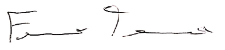

Tommaso Feraco